# Running Python

1. Normal

   ```
   $ python foo.py
   ```

2. Interactive

   ```
   $ python
   ```

3. iPython (recommended)

   ```
   $ ipython
   ```

4. Jupyter / iPython notebook (also recommended)

   ```
    $ jupyter notebook
   ```

   This is similar to iPython but browser based. It has some very cool features. For development, I have a slight preference for the simpler command-line iPython.
5. IDEs: PyCharm or Visual Studio Code

   You are on your own to figure this out. It may be very nice once setup, but you also may have some startup costs to configure it to work nicely with anaconda, matplotlib, etc. I will not support issues with IDEs.

# A typical setup

Windows open:

- Favorite text editor, e.g. sublime (write programs)
- Terminal running iPython (type commands)
- Pop up figures with matplotlib

This mimics MATLAB or R desktop environments.

Plan

- Example session
- iPython
- %run foo.py
- Some pitfalls of coding interactively

# Simple iPython notebook session

### Running a cell

A cell is a block of code. Click the cell below and press the "play" button above or type Shift+Enter. The code will run, print output, and then advance to the next cell. Type Ctrl+Enter to run but not advance.

```python
x = 2*x
print(x)
```

```
128
```

### Running code in another file

Create a file in the same directory called `hello.py` with this line

[output not shown]

Now you can run it from jupyter:

```python
%run hello.py
```

```
hello CS335
```

### Create a plot using matplotlib

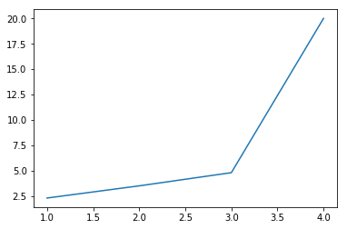

```python
%matplotlib inline
import matplotlib.pyplot as plt
x = [1, 2, 3, 4]
y = [2.3, 3.5, 4.8, 20]
plt.plot(x, y)
plt.show()
```

# Basic Data Types

## Numerical and Logical Types

```python
X=5 #Set X to integer object equal to 5
print("1: X",X)

X=5.0 #Set X to float object equal to 5.0
print("2: X=",X)

X=True #Set X to boolean True
print("3: X=",X)

X=500000000000000000000000000000000000000000000000000000000000000 # Python 3 integers have arbitrary precision
print("4: X=",X)
```

```
1: X 5
2: X= 5.0
3: X= True
4: X= 500000000000000000000000000000000000000000000000000000000000000
```

## Strings

```python
X="This is a string" #Set X to a string object defined using double quotes
print(X)
```

```
This is a string
```

```python
Y='So is this!' #Set X to a string object defined using single quotes
print(Y)
```

```
So is this!
```

```python
print(X[0])
```

```
T
```

```python
print(X[0:5] )
```

```
This
```

```python
print(X.split())
```

```
['This', 'is', 'a', 'string']
```

```python
print(X + Y)
print(X + '. ' + Y)
```

```
This is a stringSo is this!
This is a string. So is this!
```

# Containers

## Tuples

```python
X = (1,2,3,4,5)            #Define tuple
print(type(X))
```

```
<class 'tuple'>
```

```python
print("X=", X)           #Print the tuple
```

```
X= (1, 2, 3, 4, 5)
```

```python
print("X[0]=", X[0])     #Print the first element of the tuple
```

```
X[0]= 1
```

```python
print( X[4] )    #Print the last element of the tuple
print( X[-1] )   #Print the last element of the tuple
```

```
5
5
```

```python
print(len(X)) #Pring length of tuple
```

```
5
```

```python
X[0]=5                  #Set element of tuple ! ERROR (tuples are immutable)
```

```
---------------------------------------------------------------------------
TypeError                                 Traceback (most recent call last)
<ipython-input-26-21595cb19964> in <module>
----> 1 X[0]=5                  #Set element of tuple ! ERROR (tuples are immutable)

TypeError: 'tuple' object does not support item assignment
```

## Lists

```python
X = [1,2,3,4,5]         #Define list
print(type(X))           #Show type of X
```

```
<class 'list'>
```

```python
print(X)       #Print the list
```

```
[1, 2, 3, 4, 5]
```

```python
print(X[0])     #Print the first element of the list
```

```
1
```

```python
print(X[4])
print(X[-1])    #Print the last element of the list
```

```
5
5
```

```python
print(len(X))
```

```
5
```

```python
X[0] = 5                  #Change the list.
print(X)
```

```
[5, 2, 3, 4, 5]
```

```python
X.append(6)          # Append *one* item to list
print(X)
```

```
[5, 2, 3, 4, 5, 6]
```

```python
X = [1, 2, 3, 4, 5, 6]
X.extend([7, 8]) # add elements 7, 8 to end of X
print(X)
```

```
[1, 2, 3, 4, 5, 6, 7, 8]
```

```python
Y = X + [7,8]   # concatenate and retern a *new* list
print(X)
print(Y)
```

```
[1, 2, 3, 4, 5, 6, 7, 8]
[1, 2, 3, 4, 5, 6, 7, 8, 7, 8]
```

```python
X = [1, 2, 3, 4, 5]
Y=X*2           # concatenate two copies of X (think: X+X)
print(Y)
```

```
[1, 2, 3, 4, 5, 1, 2, 3, 4, 5]
```

## Dictionaries

```python
X = {"Bob": 192731, "Mary": 281927, "Joe": 103124} #Define a dictionary of key-value pairs
print("type(X)",type(X))
```

```
type(X) <class 'dict'>
```

```python
print("X=", X)                    #Print the dictionary
```

```
X= {'Bob': 192731, 'Mary': 281927, 'Joe': 103124}
```

```python
print('X["Joe"]=', X["Joe"])      #Print the value for Joe
```

```
X["Joe"]= 103124
```

```python
print('len(X)', len(X))           #Print the number of items
```

```
len(X) 3
```

```python
print('X.keys()=',X.keys())       #Print the list of keys
```

```
X.keys()= dict_keys(['Bob', 'Mary', 'Joe'])
```

```python
print('X.values()=',X.values())   #Print the list of values
```

```
X.values()= dict_values([192731, 281927, 103124])
```

```python
X["Joe"]=772345                   #Change an element
print("X=", X)
```

```
X= {'Bob': 192731, 'Mary': 281927, 'Joe': 772345}
```

```python
X["Alice"]=111111                 #Add a new element
print("X=", X)
```

```
X= {'Bob': 192731, 'Mary': 281927, 'Joe': 772345, 'Alice': 111111}
```

## Containers with Nesting and Mixed Elements

```python
X = [1,"Foo",False,[1,2,3],(1,True)] #Lists can contain mixed types!
print("X=", X)                        #Print the list
```

```
X= [1, 'Foo', False, [1, 2, 3], (1, True)]
```

```python
#How can we get the second item in the tuple at the end of the list?
print(X[-1][1])
```

```
True
```

# Assignment Dynamics

```python
A = 5  #Assign the object "5" to the name A
B = A  #Assign the object that A refers to to the name B
print("A=",A,"B=",B )
```

```
A= 5 B= 5
```

```python
B = 7
print("A=",A,"B=",B)
```

```
A= 5 B= 7
```

```python
A = [1,2,3,4,5]
B = A
print("A=",A,"B=",B )
```

```
A= [1, 2, 3, 4, 5] B= [1, 2, 3, 4, 5]
```

```python
A = [1,2,3,4,5]
B = A
B = [5,4,3,2,1]
print ("A=",A,"B=",B )
```

```
A= [1, 2, 3, 4, 5] B= [5, 4, 3, 2, 1]
```

```python
A = [1,2,3,4,5]
B=A
A.append(6)
B.append(7)
print ("A=",A,"B=",B )
```

```
A= [1, 2, 3, 4, 5, 6, 7] B= [1, 2, 3, 4, 5, 6, 7]
```

```python
A = [1,2,3,4,5]
B = A
B[0]=-1
print ("A=",A,"B=",B)
```

```
A= [-1, 2, 3, 4, 5] B= [-1, 2, 3, 4, 5]
```

# Basic Control Flow

## If-Elif-Else

```python
#Basic If-Elif-Else
X=5
if(X<0):
    print("X is negative")
elif(X==0):
    print("X is zero")
else:
    print("X is positive")
```

```
X is positive
```

## For and While

```python
#Basic for loop using range()
A = [1, 2, 3, 4, 5]
for i in range(len(A)):
    print(i, A[i])
```

```
0 1
1 2
2 3
3 4
4 5
```

```python
#Basic while loop
x=5
while(x > 0):
    print(x),
    x-=1
```

```
5
4
3
2
1
```

# Mathematical and Logical Operators

```python
print ("2**4=", 2**4 )  # Computing Powers
```

```
2**4= 16
```

```python
print ("2/4=", 2/4 )    # "True division" of int by int

# Note: the / operator for ints was "floor division"
# in Python 2.x, so would give a result of 0 for this example
```

```
2/4= 0.5
```

```python
print ("2//4=", 2//4 )  # "Floor division"
```

```
2//4= 0
```

```python
print ("2/4.=", 2/4.)   # Division of int by float (True division)
```

[output not shown]

```python
print ("2./4=", 2./4)   # Division of float by int
```

[output not shown]

```python
print ("True or False=", True or False) #Logical or
```

[output not shown]

```python
print ("True and False=", True and False) #Logical and
```

[output not shown]

```python
print ("not(False)=", not(False)) #Logical not
```

[output not shown]

# Functions

```python
def f(a):             #Define a basic function of 1-argument
    return a**2

print ("f(2)=",f(2))
```

```
f(2)= 4
```

```python
def g(h,a,b):         #Define a function of 3-arguments where h is a function and a and b are numbers
    return h(a)+h(b)

print ("g(f,2,3)=",g(f,2,3))
```

```
g(f,2,3)= 13
```

## NumPy Arrays

```python
import numpy as np
X = np.array([[1,2],[3,4],[5,6]])
print ("X=\n",X)
```

```
X=
 [[1 2]
 [3 4]
 [5 6]]
```

```python
print ("X.shape=", X.shape)
```

```
X.shape= (3, 2)
```

```python
print ("X[0,2]=", X[0,1])
```

```
X[0,2]= 2
```

```python
print ("X[0,:]=", X[0,:])
```

```
X[0,:]= [1 2]
```

```python
Y = X[0,:]
print(Y.shape)
```

```
(2,)
```

```python
print ("X[:,1]=", X[:,1])
```

```
X[:,1]= [2 4 6]
```

```python
print ("2*X=\n", 2*X)
```

```
2*X=
 [[ 2  4]
 [ 6  8]
 [10 12]]
```

```python
print ("3: 5+X=\n", 5+X)
```

```
3: 5+X=
 [[ 6  7]
 [ 8  9]
 [10 11]]
```

```python
Y = np.array([[-1,1,-1]])
print ("Y=\n",Y)
```

```
Y=
 [[-1  1 -1]]
```

```python
print ("6: Y.T=\n", Y.T)
```

```
6: Y.T=
 [[-1]
 [ 1]
 [-1]]
```

```python
print ("Y.dot(X)=\n", Y.dot(X))
```

[output not shown]

```python
print ("np.dot(Y, X)=\n", np.dot(Y, X))
```

[output not shown]

```python
print ("Y.T + X =\n", Y.T + X)
```

[output not shown]